# Question

Amelia will use 680 feet of fence to build 9 rectangular enclosures. As shown in the figure below, the 9 enclosures will be built so each one is against a barn. Neighboring enclosures will use a single fence to separate them. Let $x$ represent the length of fence perpendicular to the barn, and let $y$ represent the length of fence parallel to the barn.

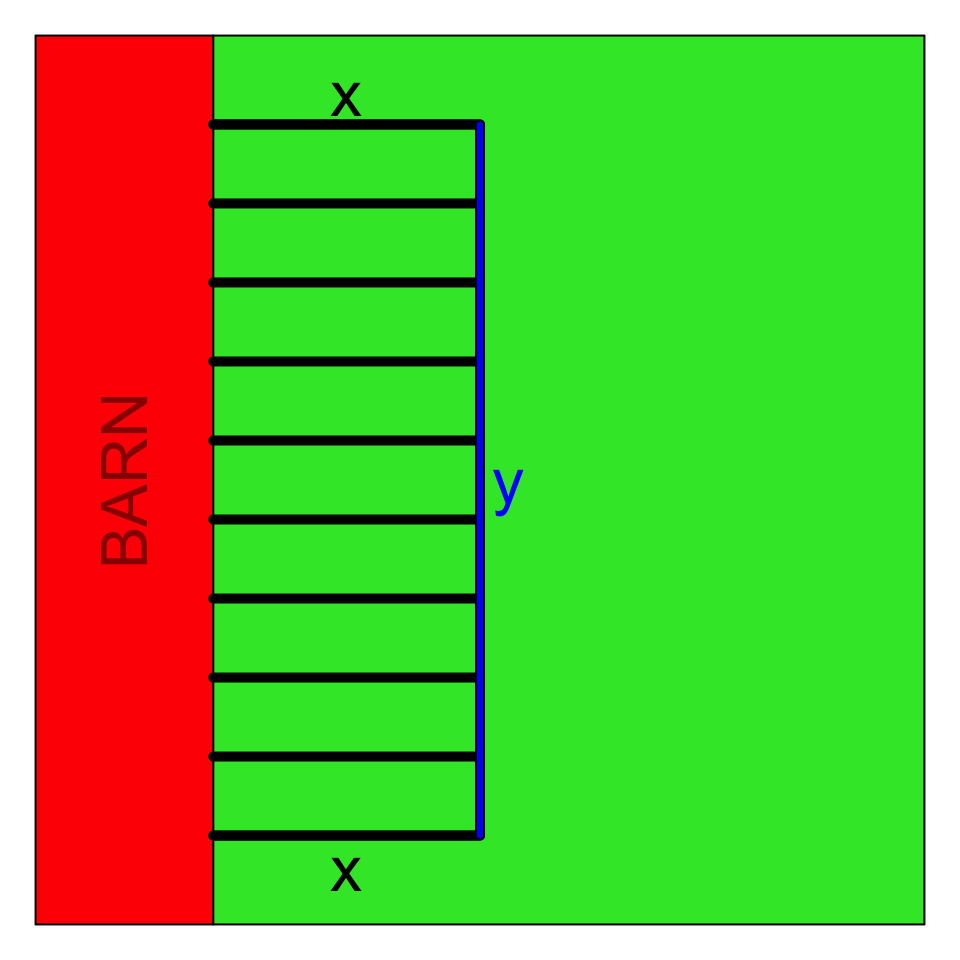

Amelia wants to maximize the total area of the enclosures. Find the value of $x$ that maximizes the area.

# Solution

The total area is simply the product of $x$ and $y$.

$$A~=~xy$$

The total length of fence is 680 feet. Notice for 9 enclosures, we need 10 lengths of $x$.

$$680~=~10x+y$$

Solve this equation for $y$ by subtracting $10x$ from both sides.

$$680-10x~=~y$$

Substitute $680-10x$ for $y$ in the area equation.

$$A~=~x\cdot(680-10x)$$

Distribute.

$$A~=~680x-10x^2$$

Put quadratic expression in standard order.

$$A~=~-10x^2+680x$$

If you draw a graph of $A$ versus $x$, you’ll get a parabola.

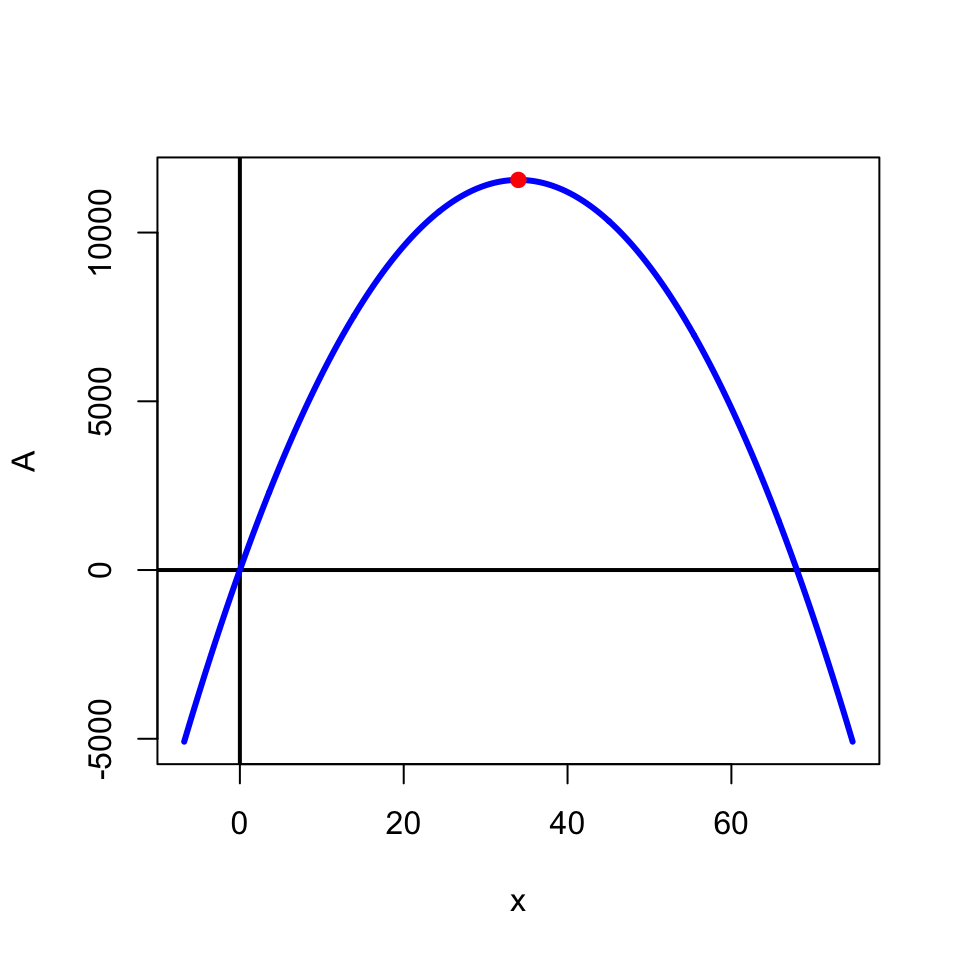

Notice, the maximum area occurs at the parabola’s vertex. So, we can use $h=\frac{-b}{2a}$ to find the optimal $x$ value.

$$x_{\text{optimal}}~=~\frac{-b}{2a}$$

$$x_{\text{optimal}}~=~\frac{-(680)}{2(-10)}$$

$$x_{\text{optimal}}~=~34$$

# Meta-information

extype: num exsolution: 34 exname: optimize_rect_fence_barn_B